# DS250 - Introduction to Data Science

Kevin Niemann

October 27, 2015

# Assignment 4

This assignment covers experiment study design, hypothesis development, common bias and error issues as well as simple predictive analytics using regression analysis and decision tries and a high level introduction to conditional probability using Bayes theorem.

### The objectives of this assignment are:

- Understand experiment types and design
- Understand common errors and bias factors
- Simple predictive analytics
- Using R to create linear regression models

#### Question 1 - Experiment Design

1. Briefly describe some common issues in experiment design:

```
Not having a representational sample, not performing a blind study, not having a valid control group for which to compare.
```

2. In a new drug study using 40 mice (20m / 20f) where half would be treated and the other half are untreated. Also the procedure is complex and is limited to 4 mice per day. What would be the most efficient approach to assign the mice by group and day?

```
Create a group each day, treating 2 m and 2 f,  and assign 2m and 2f untreated, for a total of 8 mice. Perform this four more times for five groups.
```

3. Briefly describe some of the difference between Experiment vs. Observational studies

```
An observational study is one that the researcher records data on what is observable and changing, without interfering with the results. An experiment involves applying a treatment to one group and drawing conclusions based on the differences between the two.
```

4. Create a simple experiment design for the following:

> You are tasked to complete a study of Karaoke venue(s) and identify which factors in the singer performance are most highly correlated with audience applause volume levels.

I would determine a list of factors that I believe could influence applause volume levels. For each venue I would rate the venue/singer with a applause rating for each factor between 1-5. With that data, I could correlate applause volume to the factors.

Review and complete the following questions:  
1. What kind of study is this?  
This is an observational study, I am not applying a treatment to any Karaoke venue.

2. How will you select the significant factors?  
   This based on hypothesis.
3. How many samples/subjects will you need?  
   I would use 100 samples.
4. Briefly describe your experiment approach:  
   Based on the data collected in d) I would measure the correlation between applause volume and identified factors. Then rank the factors.

#### Question 2 - Experiment Error

1. Briefly describe Type 1 experimental errors and provide two (2) examples.

```
Type 1 experimental error is the incorrect rejection of the null hypthesis (false positive). This might happen when screening for cancer or determining the effectiveness of a drug. Even though you don't have cancer and the drug doesn't work, the test rejects the null hypothesis.
```

2. Briefly describe a Type 2 error and provide two (2) examples:

```
Type 2 error is the failure to reject a null hypothesis (false negative). Conversely this would be a test incorrectly returning cancer-free or saying a drug doesn't work.
```

3. Choose and describe three (3) types of experimental bias:

```
Confirmation bias: The person running the study is looking to validate already existing beliefs, such as in 1d, the designer might select factors such as voice, clothing, without considering age etc.
Selection bias: This is bias present in who is selected to participate in the study. For example, on a political poll calling only landlines between 9AM and 5PM.
Normalcy bias: This is bias in that people don't typically expect a disaster or extreme situation. So they don't account for it as a possibility.
```

#### Question 3 - Hypothesis Definition

1. Review the following study description:

> A renown doctor claims that 17 year olds have an average body temperature higher than the average (98.6 f). After conducting a random statistical sample of 25 17 year olds, the average temperature is found to be (98.9 f) with a standard deviation of 0.6 degrees f. Reviewed. b) Identify the hypothesis in this study:

```
The average body temperature of 17 year olds is above 98.6f.
```

3. Define the null hypothesis (H0) for this study:

```
The null hypothesis is that the average body temperature of 17 year olds is not different from the average.
```

4. Identify any alternate hypothesis (Ha) applicable for this study:

The alternate hypothesis is that average body temperature of 17 year olds is above 98.6f.

#### Question 4 - Causation

For each of the following statements, assign a value from the list below:  
a. There are confounding variables  
b. It is unclear which variable is the cause and which is the effect  
c. It is unreasonable to generalize from the sample studied  
d. The variables actually measured are not related to the effect  
e. No plausible alternative explanation exists

1. A County inspector found that 35% of the sprinklers failed to activate under 7 pounds of pressure. However, the manufacturer maintains that the 7 psi threshold for passing or failing does not reflect typical water pressure in sprinkler systems.

```
e
```

2. Samoans have an increasing preference for violence as measured by the steadily increasing number of television sets being sold.

```
d
```

3. A new study suggests that women do not have the ability to be orchestra conductors since only a small percentage of orchestra conductors are women

```
c
```

#### Question 5 - Regression

1. Briefly describe the difference between linear and logistic regression:

```
 Linear regression is a model of the relationship between one dependent variable and one or more independent variables. The model has a numerical correlation between the variables. In Logistic regression, the dependent variable is a category of two values, such as Pass/Fail.
```

2. Review and run the following to create linear regression model:

```r
library(gamlss.data)
data("usair")
model.0 <- lm(y ~ x3, data = usair)
summary(model.0)
```

```
##
## Call:
## lm(formula = y ~ x3, data = usair)
##
## Residuals:
##     Min      1Q  Median      3Q     Max
## -32.545 -14.456  -4.019  11.019  72.549
##
## Coefficients:
##              Estimate Std. Error t value Pr(>|t|)
## (Intercept) 17.868316   4.713844   3.791 0.000509 ***
## x3           0.020014   0.005644   3.546 0.001035 **
## ---
## Signif. codes:  0 '***' 0.001 '**' 0.01 '*' 0.05 '.' 0.1 ' ' 1
##
## Residual standard error: 20.67 on 39 degrees of freedom
## Multiple R-squared:  0.2438, Adjusted R-squared:  0.2244
## F-statistic: 12.57 on 1 and 39 DF,  p-value: 0.001035
```

3. From the prior data set, review and run the following code to create predicted values for the model

```r
usair$prediction <- predict(model.0)
usair$residual   <- resid(model.0)
```

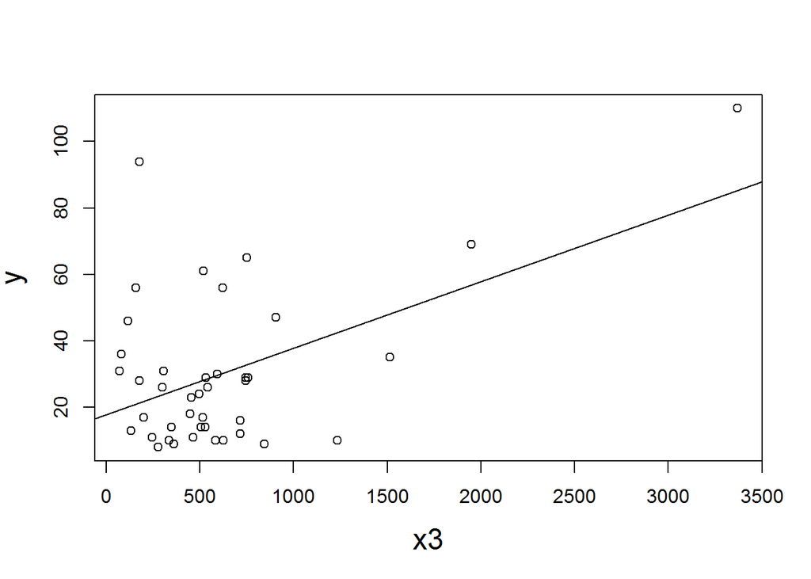

```r
plot(y ~ x3, data = usair, cex.lab = 1.5)
abline(model.0)
```

#### Question 6 - Logistic Regression

```r
cuse <- read.table("http://data.princeton.edu/wws509/datasets/cuse.dat", header=TRUE)
attach(cuse)
lrfit <- glm(cbind(using, notUsing) ~  age + education + wantsMore
            ,family = binomial)
```

#### Question 7 - Decision Trees

1. Review and run the following code:

```r
#install.packages("party")  # Install package if needed
library(party)
iris_ctree <- ctree(Species ~ Sepal.Length + Sepal.Width + Petal.Length + Petal.Width, data=iris)
```

2. Using plot(), create a plot of the decision tree.

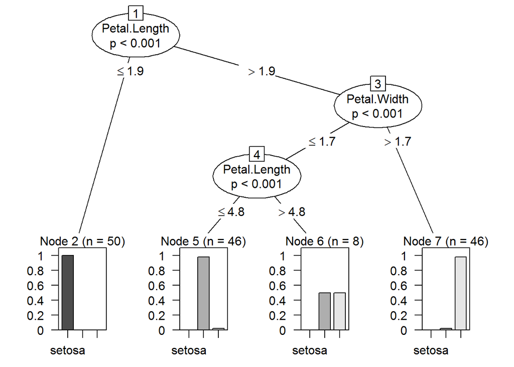

```r
plot(iris_ctree)
```

#### Question 8 - Conditional Probability

> A couple is planning their wedding at an outdoor ceremony. In recent years, it has rained only 10 days each year, however the weatherman has predicted rain for their wdding day.
1. When it does rain, the weatherman correctly forecasts rain 90% of the time.
2. When it doesn’t rain, the weatherman forecasts rain 10% of the time.

**What is the probability that it will rain on the day of the wedding?**

P(A1) = 10/365 =0.027397 P(A2) = 355/365 = 0.972602 P(B|A1) = 0.9 P(B|A2) = 0.1

P(A1|B) = (0.027397)(0.9) / ((0.027397)(0.9) + (0.972602)(0.1)) P(A1|B) = 0.202245

Probability is 20.2%.

#### Question 9 - Game Theory

1. Review the following:
- Alice and Bob are playing a game.
- There are two boxes, A and B, and Bob must choose only A or B.
- Alice secretly places either [three ($3) dollars in box A] or [two dollars ($2) in box B].
- Bob then chooses to open either A or B and gets to keep the contents of the box.
- If he chooses the empty box, Alice gets one dollar ($1).

**What should each player do to maximize their winnings?** Bob is going to pick box A just less than 50% of the time, so Alice always puts the money there. Alice will put the money in the box Bob picks less.